# Risk Factor Analysis

## Outcome Variable

**Outcome Variable:** haz

## Predictor Variables

**Intervention Variable:** parity

**Adjustment Set:**

- arm
- W_mage
- meducyrs
- feducyrs
- hhwealth_quart
- W_mhtcm
- W_mwtkg
- W_mbmi
- vagbrth
- W_nrooms
- impsan
- delta_W_mage
- delta_meducyrs
- delta_feducyrs
- delta_hhwealth_quart
- delta_W_mhtcm
- delta_W_mwtkg
- delta_W_mbmi
- delta_vagbrth
- delta_W_nrooms
- delta_impsan

## Stratifying Variables

The analysis was stratified on these variable(s):

- agecat
- studyid
- country

## Data Summary

| agecat | studyid | country | parity | n_cell | n | outcome_variable |
| --- | --- | --- | --- | --- | --- | --- |
| Birth | COHORTS | GUATEMALA | 1 | 112 | 852 | haz |
| Birth | COHORTS | GUATEMALA | 2 | 137 | 852 | haz |
| Birth | COHORTS | GUATEMALA | 3+ | 603 | 852 | haz |
| Birth | COHORTS | INDIA | 1 | 696 | 4122 | haz |
| Birth | COHORTS | INDIA | 2 | 1037 | 4122 | haz |
| Birth | COHORTS | INDIA | 3+ | 2389 | 4122 | haz |
| Birth | COHORTS | PHILIPPINES | 1 | 675 | 3050 | haz |
| Birth | COHORTS | PHILIPPINES | 2 | 687 | 3050 | haz |
| Birth | COHORTS | PHILIPPINES | 3+ | 1688 | 3050 | haz |
| Birth | GMS-Nepal | NEPAL | 1 | 211 | 696 | haz |
| Birth | GMS-Nepal | NEPAL | 2 | 180 | 696 | haz |
| Birth | GMS-Nepal | NEPAL | 3+ | 305 | 696 | haz |
| Birth | JiVitA-3 | BANGLADESH | 1 | 7456 | 22455 | haz |
| Birth | JiVitA-3 | BANGLADESH | 2 | 7615 | 22455 | haz |
| Birth | JiVitA-3 | BANGLADESH | 3+ | 7384 | 22455 | haz |
| Birth | Keneba | GAMBIA | 1 | 156 | 1407 | haz |
| Birth | Keneba | GAMBIA | 2 | 146 | 1407 | haz |
| Birth | Keneba | GAMBIA | 3+ | 1105 | 1407 | haz |
| Birth | PROVIDE | BANGLADESH | 1 | 206 | 539 | haz |
| Birth | PROVIDE | BANGLADESH | 2 | 183 | 539 | haz |
| Birth | PROVIDE | BANGLADESH | 3+ | 150 | 539 | haz |
| Birth | SAS-CompFeed | INDIA | 1 | 361 | 1252 | haz |
| Birth | SAS-CompFeed | INDIA | 2 | 289 | 1252 | haz |
| Birth | SAS-CompFeed | INDIA | 3+ | 602 | 1252 | haz |
| Birth | ZVITAMBO | ZIMBABWE | 1 | 5989 | 13874 | haz |
| Birth | ZVITAMBO | ZIMBABWE | 2 | 4144 | 13874 | haz |
| Birth | ZVITAMBO | ZIMBABWE | 3+ | 3741 | 13874 | haz |
| 6 months | COHORTS | GUATEMALA | 1 | 132 | 961 | haz |
| 6 months | COHORTS | GUATEMALA | 2 | 139 | 961 | haz |
| 6 months | COHORTS | GUATEMALA | 3+ | 690 | 961 | haz |

[output cut: 57 more lines]

The following strata were considered:

- agecat: 24 months, studyid: COHORTS, country: GUATEMALA
- agecat: 24 months, studyid: COHORTS, country: INDIA
- agecat: 24 months, studyid: COHORTS, country: PHILIPPINES
- agecat: 24 months, studyid: GMS-Nepal, country: NEPAL
- agecat: 24 months, studyid: JiVitA-3, country: BANGLADESH
- agecat: 24 months, studyid: Keneba, country: GAMBIA
- agecat: 24 months, studyid: PROVIDE, country: BANGLADESH
- agecat: 24 months, studyid: TanzaniaChild2, country: TANZANIA, UNITED REPUBLIC OF
- agecat: 24 months, studyid: ZVITAMBO, country: ZIMBABWE
- agecat: 6 months, studyid: COHORTS, country: GUATEMALA
- agecat: 6 months, studyid: COHORTS, country: INDIA
- agecat: 6 months, studyid: COHORTS, country: PHILIPPINES
- agecat: 6 months, studyid: GMS-Nepal, country: NEPAL
- agecat: 6 months, studyid: JiVitA-3, country: BANGLADESH
- agecat: 6 months, studyid: Keneba, country: GAMBIA
- agecat: 6 months, studyid: PROVIDE, country: BANGLADESH
- agecat: 6 months, studyid: SAS-CompFeed, country: INDIA
- agecat: 6 months, studyid: SAS-FoodSuppl, country: INDIA
- agecat: 6 months, studyid: TanzaniaChild2, country: TANZANIA, UNITED REPUBLIC OF
- agecat: 6 months, studyid: ZVITAMBO, country: ZIMBABWE
- agecat: Birth, studyid: COHORTS, country: GUATEMALA
- agecat: Birth, studyid: COHORTS, country: INDIA
- agecat: Birth, studyid: COHORTS, country: PHILIPPINES
- agecat: Birth, studyid: GMS-Nepal, country: NEPAL
- agecat: Birth, studyid: JiVitA-3, country: BANGLADESH
- agecat: Birth, studyid: Keneba, country: GAMBIA
- agecat: Birth, studyid: PROVIDE, country: BANGLADESH
- agecat: Birth, studyid: SAS-CompFeed, country: INDIA
- agecat: Birth, studyid: ZVITAMBO, country: ZIMBABWE

### Dropped Strata

Some strata were dropped due to rare outcomes:

- agecat: 24 months, studyid: TanzaniaChild2, country: TANZANIA, UNITED REPUBLIC OF

## Methods Detail

We’re interested in the causal parameters $E[Y_a]$ for all values of $a \in \mathcal{A}$. These parameters represent the mean outcome if, possibly contrary to fact, we intervened to set all units to have $A=a$. Under the randomization and positivity assumptions, these are identified by the statistical parameters $\psi_a=E_W[E_{Y|A,W}(Y|A=a,W)]$. In addition, we’re interested in the mean of $Y$, $E[Y]$ under no intervention (the observed mean). We will estimate these parameters by using SuperLearner to fit the relevant likelihood factors – $E_{Y|A,W}(Y|A=a,W)$ and $p(A=a|W)$, and then updating our likelihood fit using a joint TMLE.

For unadjusted analyses ($W=\{\}$), initial likelihoods were estimated using Lrnr_glm to estimate the simple $E(Y|A)$ and Lrnr_mean to estimate $p(A)$. For adjusted analyses, a small library containing Lrnr_glmnet, Lrnr_xgboost, and Lrnr_mean was used.

Having estimated these parameters, we will then use the delta method to estimate relative risks and attributable risks relative to a prespecified baseline level of $A$.

# Results Detail

## Results Plots

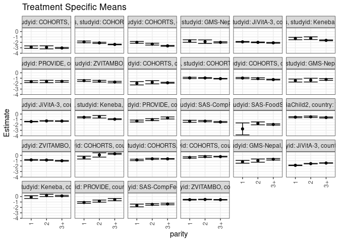

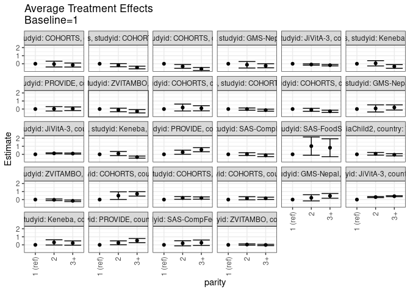

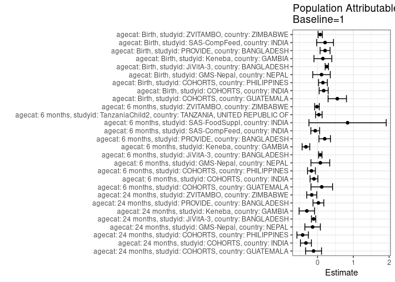

## Results Table

### Parameter: TSM

| agecat | studyid | country | intervention_level | baseline_level | estimate | ci_lower | ci_upper |
| --- | --- | --- | --- | --- | --- | --- | --- |
| Birth | COHORTS | GUATEMALA | 1 | NA | -0.4215775 | -0.6848631 | -0.1582920 |
| Birth | COHORTS | GUATEMALA | 2 | NA | 0.0658721 | -0.3282136 | 0.4599578 |
| Birth | COHORTS | GUATEMALA | 3+ | NA | 0.2877921 | 0.1928855 | 0.3826986 |
| Birth | COHORTS | INDIA | 1 | NA | -0.8480409 | -0.9799000 | -0.7161818 |
| Birth | COHORTS | INDIA | 2 | NA | -0.6450773 | -0.7417145 | -0.5484401 |
| Birth | COHORTS | INDIA | 3+ | NA | -0.6552673 | -0.7090055 | -0.6015290 |
| Birth | COHORTS | PHILIPPINES | 1 | NA | -0.3984101 | -0.5266655 | -0.2701546 |
| Birth | COHORTS | PHILIPPINES | 2 | NA | -0.2359368 | -0.3806343 | -0.0912392 |
| Birth | COHORTS | PHILIPPINES | 3+ | NA | -0.2427814 | -0.3013248 | -0.1842380 |
| Birth | GMS-Nepal | NEPAL | 1 | NA | -1.1952347 | -1.4532173 | -0.9372520 |
| Birth | GMS-Nepal | NEPAL | 2 | NA | -0.9754360 | -1.2677449 | -0.6831271 |
| Birth | GMS-Nepal | NEPAL | 3+ | NA | -0.7328254 | -0.8703704 | -0.5952803 |
| Birth | JiVitA-3 | BANGLADESH | 1 | NA | -1.8467965 | -1.8951618 | -1.7984313 |
| Birth | JiVitA-3 | BANGLADESH | 2 | NA | -1.5392323 | -1.5811759 | -1.4972886 |
| Birth | JiVitA-3 | BANGLADESH | 3+ | NA | -1.4267784 | -1.4694798 | -1.3840769 |
| Birth | Keneba | GAMBIA | 1 | NA | -0.0996333 | -0.3505440 | 0.1512775 |
| Birth | Keneba | GAMBIA | 2 | NA | 0.2079801 | -0.0007206 | 0.4166809 |
| Birth | Keneba | GAMBIA | 3+ | NA | 0.1247532 | 0.0248354 | 0.2246711 |
| Birth | PROVIDE | BANGLADESH | 1 | NA | -1.0942763 | -1.2461793 | -0.9423732 |
| Birth | PROVIDE | BANGLADESH | 2 | NA | -0.8406366 | -1.0328918 | -0.6483813 |
| Birth | PROVIDE | BANGLADESH | 3+ | NA | -0.5606211 | -0.7685142 | -0.3527279 |
| Birth | SAS-CompFeed | INDIA | 1 | NA | -1.6404168 | -1.9003938 | -1.3804398 |
| Birth | SAS-CompFeed | INDIA | 2 | NA | -1.4453712 | -1.5926818 | -1.2980607 |
| Birth | SAS-CompFeed | INDIA | 3+ | NA | -1.3746945 | -1.5177537 | -1.2316352 |
| Birth | ZVITAMBO | ZIMBABWE | 1 | NA | -0.5742891 | -0.6371188 | -0.5114594 |
| Birth | ZVITAMBO | ZIMBABWE | 2 | NA | -0.5360165 | -0.5877010 | -0.4843321 |
| Birth | ZVITAMBO | ZIMBABWE | 3+ | NA | -0.5850323 | -0.6367584 | -0.5333062 |
| 6 months | COHORTS | GUATEMALA | 1 | NA | -1.9323567 | -2.2413749 | -1.6233385 |
| 6 months | COHORTS | GUATEMALA | 2 | NA | -1.7455552 | -2.0454811 | -1.4456292 |
| 6 months | COHORTS | GUATEMALA | 3+ | NA | -1.8405630 | -1.9254477 | -1.7556782 |

[output cut: 54 more lines]

### Parameter: E(Y)

| agecat | studyid | country | intervention_level | baseline_level | estimate | ci_lower | ci_upper |
| --- | --- | --- | --- | --- | --- | --- | --- |
| Birth | COHORTS | GUATEMALA | NA | NA | 0.1297300 | 0.0458017 | 0.2136584 |
| Birth | COHORTS | INDIA | NA | NA | -0.6773241 | -0.7124609 | -0.6421873 |
| Birth | COHORTS | PHILIPPINES | NA | NA | -0.2490492 | -0.2880580 | -0.2100404 |
| Birth | GMS-Nepal | NEPAL | NA | NA | -1.0851580 | -1.1651811 | -1.0051350 |
| Birth | JiVitA-3 | BANGLADESH | NA | NA | -1.5894148 | -1.6086362 | -1.5701935 |
| Birth | Keneba | GAMBIA | NA | NA | 0.0483298 | -0.0182746 | 0.1149342 |
| Birth | PROVIDE | BANGLADESH | NA | NA | -0.8851020 | -0.9601332 | -0.8100709 |
| Birth | SAS-CompFeed | INDIA | NA | NA | -1.4314217 | -1.5099245 | -1.3529189 |
| Birth | ZVITAMBO | ZIMBABWE | NA | NA | -0.5003222 | -0.5208673 | -0.4797770 |
| 6 months | COHORTS | GUATEMALA | NA | NA | -1.8157336 | -1.8837688 | -1.7476985 |
| 6 months | COHORTS | INDIA | NA | NA | -1.0455022 | -1.0805318 | -1.0104727 |
| 6 months | COHORTS | PHILIPPINES | NA | NA | -1.1405724 | -1.1824954 | -1.0986493 |
| 6 months | GMS-Nepal | NEPAL | NA | NA | -1.3508392 | -1.4290633 | -1.2726152 |
| 6 months | JiVitA-3 | BANGLADESH | NA | NA | -1.3130932 | -1.3362359 | -1.2899505 |
| 6 months | Keneba | GAMBIA | NA | NA | -0.9239386 | -0.9768148 | -0.8710623 |
| 6 months | PROVIDE | BANGLADESH | NA | NA | -1.0916915 | -1.1661176 | -1.0172654 |
| 6 months | SAS-CompFeed | INDIA | NA | NA | -1.4018563 | -1.4810585 | -1.3226541 |
| 6 months | SAS-FoodSuppl | INDIA | NA | NA | -1.8986842 | -2.0118892 | -1.7854792 |
| 6 months | TanzaniaChild2 | TANZANIA, UNITED REPUBLIC OF | NA | NA | -0.5432778 | -0.5926218 | -0.4939338 |
| 6 months | ZVITAMBO | ZIMBABWE | NA | NA | -0.8679886 | -0.8935535 | -0.8424236 |
| 24 months | COHORTS | GUATEMALA | NA | NA | -2.9905921 | -3.0548289 | -2.9263553 |
| 24 months | COHORTS | INDIA | NA | NA | -2.2397574 | -2.2808841 | -2.1986307 |
| 24 months | COHORTS | PHILIPPINES | NA | NA | -2.4141145 | -2.4590818 | -2.3691473 |
| 24 months | GMS-Nepal | NEPAL | NA | NA | -1.8874180 | -1.9728588 | -1.8019773 |
| 24 months | JiVitA-3 | BANGLADESH | NA | NA | -2.0136481 | -2.0413552 | -1.9859409 |
| 24 months | Keneba | GAMBIA | NA | NA | -1.5883084 | -1.6443765 | -1.5322402 |
| 24 months | PROVIDE | BANGLADESH | NA | NA | -1.6024221 | -1.6857420 | -1.5191023 |
| 24 months | ZVITAMBO | ZIMBABWE | NA | NA | -1.6059640 | -1.6629797 | -1.5489484 |

### Parameter: ATE

| agecat | studyid | country | intervention_level | baseline_level | estimate | ci_lower | ci_upper |
| --- | --- | --- | --- | --- | --- | --- | --- |
| Birth | COHORTS | GUATEMALA | 1 | 1 | 0.0000000 | 0.0000000 | 0.0000000 |
| Birth | COHORTS | GUATEMALA | 2 | 1 | 0.4874497 | 0.0143583 | 0.9605410 |
| Birth | COHORTS | GUATEMALA | 3+ | 1 | 0.7093696 | 0.4323928 | 0.9863465 |
| Birth | COHORTS | INDIA | 1 | 1 | 0.0000000 | 0.0000000 | 0.0000000 |
| Birth | COHORTS | INDIA | 2 | 1 | 0.2029636 | 0.0396919 | 0.3662353 |
| Birth | COHORTS | INDIA | 3+ | 1 | 0.1927736 | 0.0506571 | 0.3348901 |
| Birth | COHORTS | PHILIPPINES | 1 | 1 | 0.0000000 | 0.0000000 | 0.0000000 |
| Birth | COHORTS | PHILIPPINES | 2 | 1 | 0.1624733 | -0.0302304 | 0.3551770 |
| Birth | COHORTS | PHILIPPINES | 3+ | 1 | 0.1556286 | 0.0151493 | 0.2961080 |
| Birth | GMS-Nepal | NEPAL | 1 | 1 | 0.0000000 | 0.0000000 | 0.0000000 |
| Birth | GMS-Nepal | NEPAL | 2 | 1 | 0.2197987 | -0.1684228 | 0.6080201 |
| Birth | GMS-Nepal | NEPAL | 3+ | 1 | 0.4624093 | 0.1687499 | 0.7560687 |
| Birth | JiVitA-3 | BANGLADESH | 1 | 1 | 0.0000000 | 0.0000000 | 0.0000000 |
| Birth | JiVitA-3 | BANGLADESH | 2 | 1 | 0.3075643 | 0.2459442 | 0.3691843 |
| Birth | JiVitA-3 | BANGLADESH | 3+ | 1 | 0.4200182 | 0.3584275 | 0.4816089 |
| Birth | Keneba | GAMBIA | 1 | 1 | 0.0000000 | 0.0000000 | 0.0000000 |
| Birth | Keneba | GAMBIA | 2 | 1 | 0.3076134 | -0.0184021 | 0.6336289 |
| Birth | Keneba | GAMBIA | 3+ | 1 | 0.2243865 | -0.0453239 | 0.4940969 |
| Birth | PROVIDE | BANGLADESH | 1 | 1 | 0.0000000 | 0.0000000 | 0.0000000 |
| Birth | PROVIDE | BANGLADESH | 2 | 1 | 0.2536397 | 0.0093541 | 0.4979253 |
| Birth | PROVIDE | BANGLADESH | 3+ | 1 | 0.5336552 | 0.2764900 | 0.7908204 |
| Birth | SAS-CompFeed | INDIA | 1 | 1 | 0.0000000 | 0.0000000 | 0.0000000 |
| Birth | SAS-CompFeed | INDIA | 2 | 1 | 0.1950455 | -0.1219996 | 0.5120907 |
| Birth | SAS-CompFeed | INDIA | 3+ | 1 | 0.2657223 | -0.0726825 | 0.6041271 |
| Birth | ZVITAMBO | ZIMBABWE | 1 | 1 | 0.0000000 | 0.0000000 | 0.0000000 |
| Birth | ZVITAMBO | ZIMBABWE | 2 | 1 | 0.0382725 | -0.0429114 | 0.1194564 |
| Birth | ZVITAMBO | ZIMBABWE | 3+ | 1 | -0.0107432 | -0.0920248 | 0.0705383 |
| 6 months | COHORTS | GUATEMALA | 1 | 1 | 0.0000000 | 0.0000000 | 0.0000000 |
| 6 months | COHORTS | GUATEMALA | 2 | 1 | 0.1868015 | -0.2435348 | 0.6171379 |
| 6 months | COHORTS | GUATEMALA | 3+ | 1 | 0.0917937 | -0.2281917 | 0.4117792 |

[output cut: 54 more lines]

### Parameter: PAR

| agecat | studyid | country | intervention_level | baseline_level | estimate | ci_lower | ci_upper |
| --- | --- | --- | --- | --- | --- | --- | --- |
| Birth | COHORTS | GUATEMALA | 1 | NA | 0.5513076 | 0.2942582 | 0.8083569 |
| Birth | COHORTS | INDIA | 1 | NA | 0.1707168 | 0.0435938 | 0.2978398 |
| Birth | COHORTS | PHILIPPINES | 1 | NA | 0.1493609 | 0.0268894 | 0.2718323 |
| Birth | GMS-Nepal | NEPAL | 1 | NA | 0.1100766 | -0.1351844 | 0.3553376 |
| Birth | JiVitA-3 | BANGLADESH | 1 | NA | 0.2573817 | 0.2122447 | 0.3025187 |
| Birth | Keneba | GAMBIA | 1 | NA | 0.1479630 | -0.1010431 | 0.3969692 |
| Birth | PROVIDE | BANGLADESH | 1 | NA | 0.2091742 | 0.0698553 | 0.3484932 |
| Birth | SAS-CompFeed | INDIA | 1 | NA | 0.2089950 | -0.0271787 | 0.4451688 |
| Birth | ZVITAMBO | ZIMBABWE | 1 | NA | 0.0739669 | 0.0149061 | 0.1330276 |
| 6 months | COHORTS | GUATEMALA | 1 | NA | 0.1166231 | -0.1844439 | 0.4176900 |
| 6 months | COHORTS | INDIA | 1 | NA | -0.1015859 | -0.2105807 | 0.0074090 |
| 6 months | COHORTS | PHILIPPINES | 1 | NA | -0.1707909 | -0.2800364 | -0.0615453 |
| 6 months | GMS-Nepal | NEPAL | 1 | NA | 0.0769149 | -0.1854417 | 0.3392715 |
| 6 months | JiVitA-3 | BANGLADESH | 1 | NA | 0.0749458 | 0.0271848 | 0.1227069 |
| 6 months | Keneba | GAMBIA | 1 | NA | -0.3248566 | -0.4318766 | -0.2178367 |
| 6 months | PROVIDE | BANGLADESH | 1 | NA | 0.2000205 | 0.0380401 | 0.3620010 |
| 6 months | SAS-CompFeed | INDIA | 1 | NA | -0.0664109 | -0.1884110 | 0.0555892 |
| 6 months | SAS-FoodSuppl | INDIA | 1 | NA | 0.8384586 | -0.2422291 | 1.9191464 |
| 6 months | TanzaniaChild2 | TANZANIA, UNITED REPUBLIC OF | 1 | NA | 0.0353742 | -0.0560980 | 0.1268465 |
| 6 months | ZVITAMBO | ZIMBABWE | 1 | NA | -0.0165032 | -0.0809090 | 0.0479026 |
| 24 months | COHORTS | GUATEMALA | 1 | NA | -0.1127859 | -0.3366292 | 0.1110574 |
| 24 months | COHORTS | INDIA | 1 | NA | -0.3252522 | -0.4761591 | -0.1743452 |
| 24 months | COHORTS | PHILIPPINES | 1 | NA | -0.4176574 | -0.5776871 | -0.2576277 |
| 24 months | GMS-Nepal | NEPAL | 1 | NA | -0.1388203 | -0.3554567 | 0.0778162 |
| 24 months | JiVitA-3 | BANGLADESH | 1 | NA | -0.1110404 | -0.1713057 | -0.0507751 |
| 24 months | Keneba | GAMBIA | 1 | NA | -0.3003619 | -0.5166440 | -0.0840798 |
| 24 months | PROVIDE | BANGLADESH | 1 | NA | 0.0229581 | -0.1277589 | 0.1736752 |
| 24 months | ZVITAMBO | ZIMBABWE | 1 | NA | -0.1640831 | -0.3039204 | -0.0242457 |